# act_report

## Report: act_report

- Create a **250-word-minimum written report** called "act_report.pdf" or "act_report.html" that communicates the insights and displays the visualization(s) produced from your wrangled data. This is to be framed as an external document, like a blog post or magazine article, for example.

### What is the most common platform from which people tweet?

There are four sources for these 2097 tweets, 93.7% of which are from "Tweet for iPhone". That's a big majority, much larger than the sum of the other three sources: Vine, Twitter Web Client, and TweetDeck. It shows the majority of twitter users are using their mobile phones to access Twitter, and that suggests the design efforts of Twitter should be spent more on this group to encourage them to use Twitter more.

### Which rating is given the most frequently?

23.4% of tweets are rated as 1.2. 20.9% of tweets are rated as 1.0. 20% of the tweets are rated as 1.1. 13.7% of the tweets are rated as 1.3. More than half of the ratings are above the denominator 10, so there is no wonder why this account owns huge popularity due to its generosity, kindness and sense of humour.

### The most liked tweet

The original tweet are with a short video to show a doggo's enlightment moment of realizing it can stand in the pool. Very funny. And the url for the original tweet is https://twitter.com/dog_rates/status/744234799360020481. Have fun!

[figure not shown]

### Most popular dog breeds

The neural network identified the dog breed in 94% of all tweets. From those results, we can clearly see:

- The most popular dog breed is golden-retriever with 156 tweets (8%).
- Other popular breeds are Labrador-retriever, Pembroke, Chihuahua, pug, toy-poodle, chow, Samoyed, Pomeranian, and malamute.

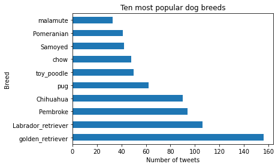